# An Introduction to Simle Regression

Robert Barr

2022-11-13

## Predicting an outcome from a model

Almost if not all data can be predicted using this general equation:

- outcome<sub>i</sub> = (model) + error<sub>i</sub>

## Regression Concepts

- What is regression?
  - The statistical analysis studying the relationship between a set of independent variables (explanatory variables) and dependent variables (response variables)
  - Regression Analysis: Fit a model to your data and use it to predict values of the dependent variable (DV) from one or more independent variables (IVs)
    - Simple Regression: predicting an outcome variable from one predictor variable
    - Multiple Regression: Predicting an outcome variable from several predictor variables.
  - Regression versus Correlation
    - Regression analysis develops a statistical model used to **predict** the values of a dependent variable based on the value(s) of independent predictor variable(s).
    - Correlation measures the **intensity** of the relationship between variables

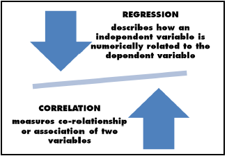

      Regression vs Correlation

  - Types of Regression
    - Linear
    - Nonlinear
  - Using the general equation:
    - outcome<sub>i</sub> = (linear model) + error<sub>i</sub>
    - linear model:
      - The values defining our ‘fit’ line
        - slope (gradient) denoted by *b<sub>1</sub>*
        - The point where the line crosses the vertical axis - knows as the *intercept* *b<sub>0</sub>*
    - The general equation becomes a regression model:
      - Y<sub>i</sub> = (*b<sub>0</sub>* + *b<sub>1</sub>*X<sub>i</sub>) + Ɛ<sub>i</sub> (Y<sub>i</sub> = (β<sub>0</sub> + β<sub>1</sub> X<sub>i</sub>) + ε<sub>i</sub>)
        - Y<sub>i</sub> is what you want to predict
        - X<sub>i</sub> is the predictor variable
        - *b<sub>i</sub>* is the line slope/gradient
          - Tells us if there is a positive or negative relationship.
        - *b<sub>0</sub>* is the intercept
        - Ɛ<sub>i</sub> represents the difference (residual) between whats predicted versus what was actual

        > (**NOTE:** *b<sub>0</sub>* and *b<sub>1</sub>* are known as the **regression coefficients**)

## Is my regression good?

- How can you know how well your line will accurately predict data?
  - The method of least squares: The ‘line of best fit’ is that line of all lines with the least amount of difference between observed and prediction line.

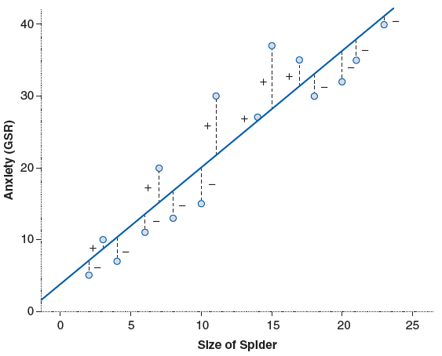

  Line of Best Fit

  - Summing the positive and negative differences (residuals) tend to cancel each other out. To prevent this effect, square the differences and then add them up.
    - If the squared residuals is large the line does not represent the data. If the squared differences is small: the line is representative.
    - **Method of Least Squares**: Determines the line (of all possible) with the lowest SS.

## Determinging Goodness of Fit

After determining the “line of best fit” compare that line using the actual data.

## Are my predictors any good?

Recall the regression model: Y<sub>i</sub> = (*b<sub>0</sub>* + *b<sub>1</sub>*X<sub>i</sub>) + Ɛ<sub>i</sub> - b<sub>1</sub> is the predictor variables coefficient. It is the change in the outcome resulting from a unit change in the predictor. A bad model will have the value of zero for it’s predictor variable. - the t-statistic test if the coefficient is 0 … aka the null hypothesis.

## Example: Album Sales

# The lm() function

- Specify the lm() formula symbolically
  - formula = response **~** terms
    - **response** - the numeric response vector
    - **terms** - a series of terms specifying a line predictor for response
      - A + B: All terms in A plus all terms in B **without duplicates**
      - A : B: The interaction of **all** terms of A with **all* the terms of B
      - A * B: The cross of A and B

```r
df_album_sales.1 <- read.delim("Album Sales 1.dat", header = TRUE)
df_album_sales.2 <- read.delim("Album Sales 2.dat", header = TRUE)

str(df_album_sales.1)
```

```
## 'data.frame':    200 obs. of  2 variables:
##  $ adverts: num  10.3 985.7 1445.6 1188.2 574.5 ...
##  $ sales  : int  330 120 360 270 220 170 70 210 200 300 ...
```

```r
summary(df_album_sales.1)
```

```
##     adverts             sales
##  Min.   :   9.104   Min.   : 10.0
##  1st Qu.: 215.918   1st Qu.:137.5
##  Median : 531.916   Median :200.0
##  Mean   : 614.412   Mean   :193.2
##  3rd Qu.: 911.226   3rd Qu.:250.0
##  Max.   :2271.860   Max.   :360.0
```

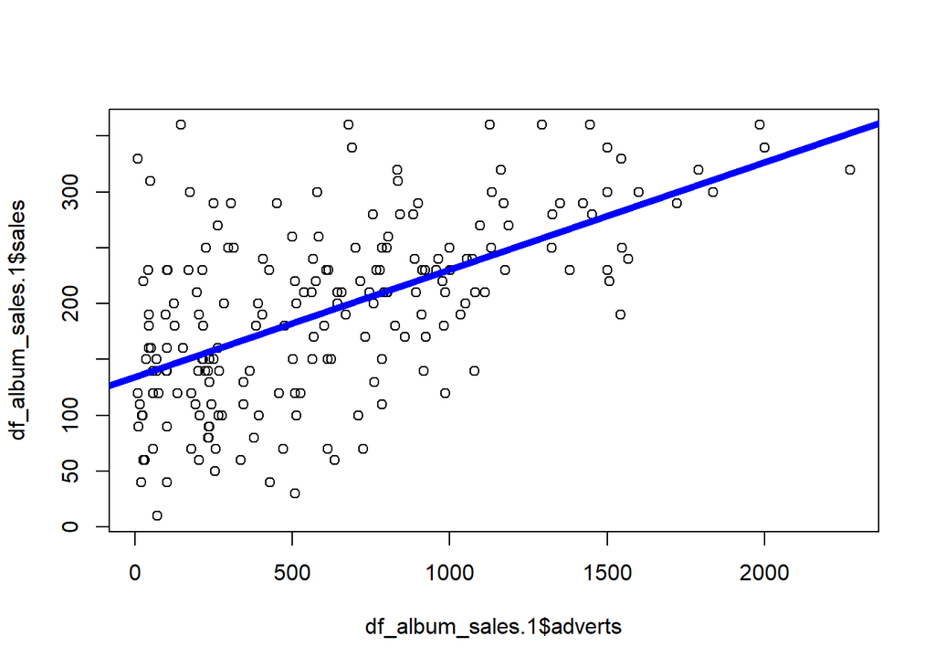

```r
plot(x = df_album_sales.1$adverts, y = df_album_sales.1$sales)
abline(
  lm(formula = df_album_sales.1$sales ~ df_album_sales.1$adverts, na.action =  na.fail),
  col = 'blue',
  lwd = 5
)
```

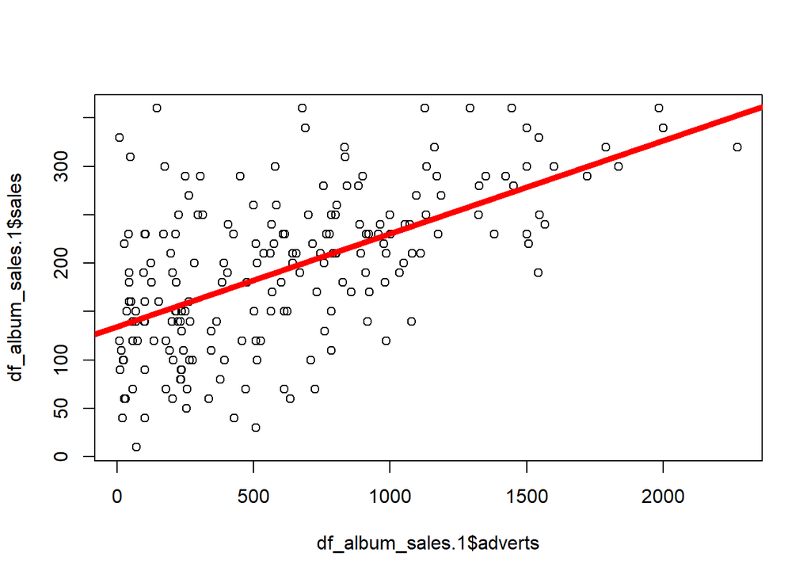

```r
plot(x = df_album_sales.1$adverts, y = df_album_sales.1$sales)
abline(
  lm(formula = sales ~ adverts, data = df_album_sales.1, na.action =  na.fail),
  col = 'red',
  lwd = 5
)
```

```r
reg_album_sales.1 <- lm(formula = sales ~ adverts, data = df_album_sales.1, na.action = na.fail)
reg_album_sales.1
```

```
##
## Call:
## lm(formula = sales ~ adverts, data = df_album_sales.1, na.action = na.fail)
##
## Coefficients:
## (Intercept)      adverts
##   134.13994      0.09612
```

```r
## The Regression Model
#sales = adverts*b + intercept
#sales = adverts * 0.09612 + 134.13994

summary(reg_album_sales.1)
```

```
##
## Call:
## lm(formula = sales ~ adverts, data = df_album_sales.1, na.action = na.fail)
##
## Residuals:
##      Min       1Q   Median       3Q      Max
## -152.949  -43.796   -0.393   37.040  211.866
##
## Coefficients:
##              Estimate Std. Error t value Pr(>|t|)
## (Intercept) 1.341e+02  7.537e+00  17.799   <2e-16 ***
## adverts     9.612e-02  9.632e-03   9.979   <2e-16 ***
## ---
## Signif. codes:  0 '***' 0.001 '**' 0.01 '*' 0.05 '.' 0.1 ' ' 1
##
## Residual standard error: 65.99 on 198 degrees of freedom
## Multiple R-squared:  0.3346, Adjusted R-squared:  0.3313
## F-statistic: 99.59 on 1 and 198 DF,  p-value: < 2.2e-16
```

```r
#Overall Fit
# R^2 0.3346
r <- sqrt(0.3346)
```

## Example: Selling Printers

```r
df_printer_sales <- read.csv("SellingPrinters.csv", header = TRUE, sep = ";")
str(df_printer_sales)
```

```
## 'data.frame':    20 obs. of  3 variables:
##  $ X         : chr  "Store1" "Store2" "Store3" "Store4" ...
##  $ Sold.Items: int  100 150 130 140 110 160 115 135 120 155 ...
##  $ Price     : int  60 43 48 45 55 40 53 47 52 42 ...
```

```r
head(df_printer_sales)
```

```
##        X Sold.Items Price
## 1 Store1        100    60
## 2 Store2        150    43
## 3 Store3        130    48
## 4 Store4        140    45
## 5 Store5        110    55
## 6 Store6        160    40
```

```r
plot(x = df_printer_sales$Sold.Items, y = df_printer_sales$Price, cex = .75, lwd = 5, main = "Scatter Plot: Price as a function of units sold", xlab = "Number Sold", ylab = "Price")

# Covariance
cov(df_printer_sales$Sold.Items, df_printer_sales$Price) # -107.8105
```

[output not shown]

```
## [1] -107.8105
```

```r
# Standard Deviation
sd(df_printer_sales$Sold.Items)
```

```
## [1] 19.15202
```

```r
sd(df_printer_sales$Price)
```

```
## [1] 5.848077
```

```r
# Correlation Coefficient
cor(df_printer_sales$Sold.Items, df_printer_sales$Price) # -0.9625725
```

```
## [1] -0.9625725
```

```r
# Simple Linear Regression
reg_printer_sales <- lm(formula =df_printer_sales$Price ~ df_printer_sales$Sold.Items, na.action = na.fail)
reg_printer_sales
```

```
##
## Call:
## lm(formula = df_printer_sales$Price ~ df_printer_sales$Sold.Items,
##     na.action = na.fail)
##
## Coefficients:
##                 (Intercept)  df_printer_sales$Sold.Items
##                     85.9565                      -0.2939
```

```r
summary(reg_printer_sales)
```

```
##
## Call:
## lm(formula = df_printer_sales$Price ~ df_printer_sales$Sold.Items,
##     na.action = na.fail)
##
## Residuals:
##    Min     1Q Median     3Q    Max
## -2.277 -1.353  0.223  1.177  3.436
##
## Coefficients:
##                             Estimate Std. Error t value Pr(>|t|)
## (Intercept)                 85.95647    2.60429   33.01  < 2e-16 ***
## df_printer_sales$Sold.Items -0.29392    0.01951  -15.07 1.19e-11 ***
## ---
## Signif. codes:  0 '***' 0.001 '**' 0.01 '*' 0.05 '.' 0.1 ' ' 1
##
## Residual standard error: 1.628 on 18 degrees of freedom
## Multiple R-squared:  0.9265, Adjusted R-squared:  0.9225
## F-statistic: 227.1 on 1 and 18 DF,  p-value: 1.195e-11
```

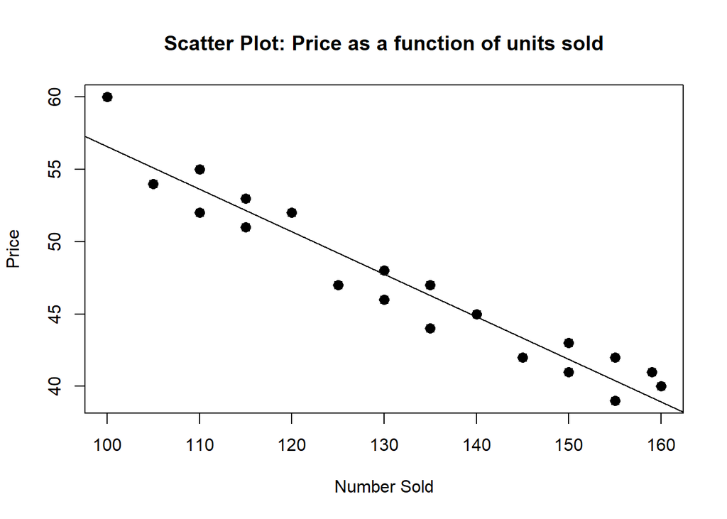

```r
# Printer a scatter plot and add a best of fit line
plot(x = df_printer_sales$Sold.Items, y = df_printer_sales$Price, cex = .75, lwd = 5, main = "Scatter Plot: Price as a function of units sold", xlab = "Number Sold", ylab = "Price")
abline(reg_printer_sales)
```

## Example: Licensed Drivers

```r
# install.packages("readxl")
library(readxl)

dat_LicDrivers <- read_excel("LicensedDrivers.xlsx")
str(dat_LicDrivers)
```

```
## tibble [52 × 2] (S3: tbl_df/tbl/data.frame)
##  $ Year           : num [1:52] 1960 1961 1962 1963 1964 ...
##  $ LicensedDrivers: num [1:52] 87 89 91 94 95 99 101 103 105 108 ...
```

```r
# Fit a regression model to predict number of licensed drivers in the US in millions by using Year
reg_LicDrivers <- lm(dat_LicDrivers$LicensedDrivers ~ dat_LicDrivers$Year, na.action = na.fail)
reg_LicDrivers
```

```
##
## Call:
## lm(formula = dat_LicDrivers$LicensedDrivers ~ dat_LicDrivers$Year,
##     na.action = na.fail)
##
## Coefficients:
##         (Intercept)  dat_LicDrivers$Year
##           -4844.307                2.517
```

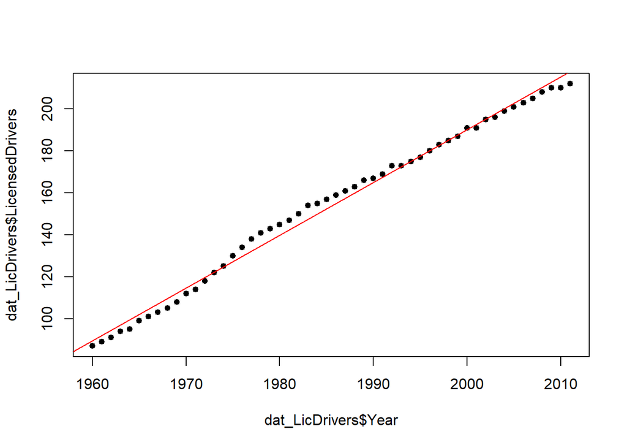

```r
# Number of Licensed Drivers = -4844.307 + 2.517 * Year

# Plot
plot(x = dat_LicDrivers$Year, y = dat_LicDrivers$LicensedDrivers, cex = .25, lwd = 5)
abline(reg_LicDrivers, col = 'red')
```

```r
summary(reg_LicDrivers)
```

```
##
## Call:
## lm(formula = dat_LicDrivers$LicensedDrivers ~ dat_LicDrivers$Year,
##     na.action = na.fail)
##
## Residuals:
##     Min      1Q  Median      3Q     Max
## -5.9601 -2.8996 -0.3038  3.0582  6.5240
##
## Coefficients:
##                       Estimate Std. Error t value Pr(>|t|)
## (Intercept)         -4.844e+03  6.445e+01  -75.17   <2e-16 ***
## dat_LicDrivers$Year  2.517e+00  3.246e-02   77.56   <2e-16 ***
## ---
## Signif. codes:  0 '***' 0.001 '**' 0.01 '*' 0.05 '.' 0.1 ' ' 1
##
## Residual standard error: 3.513 on 50 degrees of freedom
## Multiple R-squared:  0.9918, Adjusted R-squared:  0.9916
## F-statistic:  6015 on 1 and 50 DF,  p-value: < 2.2e-16
```

## Resources

- [Discovering statistics using R, Sage Publishing](https://studysites.sagepub.com/dsur/main.htm)